# Applied Statistics - Week 1: Introduction to R

BL Mosby

5/13/21

## Welcome to R!

Throughout this term, we will use R Markdown (or .Rmd) files to keep our weekly live session code and assignment code organized. Today, we’ll start with our first .Rmd file.

R Markdown files are a combination of regular text for humans to read, and R code, for the computer to execute. Here, you can enter text that you want to print out in your final output file. There are few different symbols used to bold, italicize, and so on:

*This text is in italics*

**This text is in bold print**

And below this text is a horizontal line:

When we are ready to add in code, we will create what is called a “code chunk.” These chunks tell R to interpret what’s in them as code (rather than text).

```r
#You can also include notes in code chunks; however, to let R know that they are text and not code, they need to begin with the # symbol.

#First we will see how R can perform simple calculations
#Suppose we want to calculate 2+2
2+2 #you can add notes anywhere
```

```
## [1] 4
```

Let’s try some more addition problems - R can do them all!

```r
184+32
```

```
## [1] 216
```

```r
158976+2546
```

```
## [1] 161522
```

What about the square root of 9?

```r
sqrt(9) #sqrt is an example of a built-in R function - we'll learn a lot of these this semester
```

```
## [1] 3
```

Additional calculations using R as a calculator

```r
9-2
```

```
## [1] 7
```

```r
9^2 #the carrot ^ symbol is used to exponentiate
```

```
## [1] 81
```

```r
3*6 #asterisk * is used for multiplication
```

```
## [1] 18
```

## Defining objects in R

R stores things (data, output, etc.) as objects. We will learn this term how to store the findings from statistical analyses as objects, but let’s start with a simpler case. We can assign values to objects (let’s call them x and y) and then do the calculations with those objects. this practice is especially handy if you’re going to want to use the same number (or object) in numerous calculations.

To assign an object in R, you choose a name for that object and then tell R what the object is equal to.

```r
#let's assign the number 9 to an object named x
x <- 9 #we can do this using a backwards arrow

#you can also assign objects using the equals sign
z = 4

y <- 2 #this assigns the number 2 to y

#Note: you don't have to choose single-letter object names
ollietheobject <- 52
```

When we run/execute the code chunk above, notice what appears in your global environment (top right box in RStudio). Objects are stored here. This way, you can use them again in future lines of code.

Let’s use some of our stored objects in calculations.

```r
y+z #what numbers do these objects represent? What answers do we expect here?
```

```
## [1] 6
```

```r
sqrt(x)
```

```
## [1] 3
```

```r
ollietheobject - y
```

```
## [1] 50
```

```r
z^y
```

```
## [1] 16
```

Next, we will learn how to create vectors and dataframes and store those as objects in R.

To create a vector of elements, we use the code: c(element, element, element,…)

```r
#Let's create a vector with the following numbers: 4 5 63 67 89
vector1 <- c(4,5,63,67,89) #concatenate

#Let's create another vector with the numbers: 88 92 71 69 99
vector2 <- c(88, 92, 71, 69, 99)

mean(vector2)
```

```
## [1] 83.8
```

```r
#now let's create a vector with string (or non-numeric) data: dog, cat, bunny
vectorstring <- c("dog", "cat", "bunny") #for non-numeric data, we use "" to show R that these aren't numbers
```

To view (or “print”) an object, you can simply enter the name of the object, and R will reveal what is assigned to the object.

```r
#print the ollietheobject object
ollietheobject
```

```
## [1] 52
```

```r
#print our string vector
vectorstring
```

```
## [1] "dog"   "cat"   "bunny"
```

```r
#print our numeric vector
vector1
```

```
## [1]  4  5 63 67 89
```

Sometimes, we have two vectors that are related (i.e., they are from the same dataset) and we want to put them together in a single data frame. We can do this using another built-in R function.

```r
#Let's make a dataframe out of our two numeric vectors. We can do this because they're both
#the same size (5 elements each). I'm going to store the dataframe in an object.
week1dataframe <- data.frame(vector1, vector2)

#print the dataframe
week1dataframe
```

```
##   vector1 vector2
## 1       4      88
## 2       5      92
## 3      63      71
## 4      67      69
## 5      89      99
```

data.frame is a function – we will be using a lot of functions. If you need help with a function you can just type help() with the name of the function in the ()

```r
#help(data.frame)
```

Suppose we want to change the names of our vectors within in our dataframe so that they are meaningful and tell us something about the data. For the vectors we have, let’s say that vector 1 is the student ID and vector 2 is the student’s last grade on an exam.

```r
names(week1dataframe) <- c("SID", "Score")

week1dataframe
```

```
##   SID Score
## 1   4    88
## 2   5    92
## 3  63    71
## 4  67    69
## 5  89    99
```

Let’s say we also have data on student sex and want to add that to our existing dataframe. We can also do that. We’re going to use the $ symbol after our dataframe name to let R know that we want to attach the new vector to the existing data.

```r
#let's add a new variable: Sex
week1dataframe$Sex <- c("M","F","F","M","F")

week1dataframe
```

```
##   SID Score Sex
## 1   4    88   M
## 2   5    92   F
## 3  63    71   F
## 4  67    69   M
## 5  89    99   F
```

```r
#let's add another variable: age
week1dataframe$Age = c(29,20,25,27,35)

week1dataframe
```

```
##   SID Score Sex Age
## 1   4    88   M  29
## 2   5    92   F  20
## 3  63    71   F  25
## 4  67    69   M  27
## 5  89    99   F  35
```

If we just want to view the values from one variable in a dataframe, you can use call attention to just one variable (or column) with that same $ symbol.

```r
#let's just look at the sex data
week1dataframe$Sex
```

```
## [1] "M" "F" "F" "M" "F"
```

```r
wk1df <- data.frame(week1dataframe$Sex, vector1, vector2)
```

## Frequency Distributions

Next, we’re going to learn how to create an ungrouped frequency distribution. First, we will create a vector from the math ability data in async.

```r
mathability <- c(6,5,6,1,4,4,5,6,5,3,5,6,7,3,5,5,4,5,4,7,2,5,5,2,6,5,5,4,5,3,5,7,6,5,3)
mathability
```

```
##  [1] 6 5 6 1 4 4 5 6 5 3 5 6 7 3 5 5 4 5 4 7 2 5 5 2 6 5 5 4 5 3 5 7 6 5 3
```

Then, we’re going to use R’s built in “table” function to create a frequency table.

```r
mathtable <- table(mathability)

#Let's make the table look a little better using transform - this is like the transpose function in excel
transform(mathtable)
```

```
##   mathability Freq
## 1           1    1
## 2           2    2
## 3           3    4
## 4           4    5
## 5           5   14
## 6           6    6
## 7           7    3
```

Now, let’s add some information to the table (percent, cumulative frequency and cumulative percent)

```r
freq_table <- transform(table(mathability)) #save the pretty table to an object
n <- length(mathability) #store the total number of elements in the original vector in the object n

#built the table - adding relative frequency, cumulative frequency, and cumulative percent
transform(freq_table, Rel_Freq=prop.table(Freq), Cum_Freq=cumsum(Freq), Cum_Percent=(cumsum(Freq)/n))
```

```
##   mathability Freq   Rel_Freq Cum_Freq Cum_Percent
## 1           1    1 0.02857143        1  0.02857143
## 2           2    2 0.05714286        3  0.08571429
## 3           3    4 0.11428571        7  0.20000000
## 4           4    5 0.14285714       12  0.34285714
## 5           5   14 0.40000000       26  0.74285714
## 6           6    6 0.17142857       32  0.91428571
## 7           7    3 0.08571429       35  1.00000000
```

In addition to building tables and doing computations incredibly fast, R is also DYNO-MITE at visual depictions of data. Let’s start with a very simple example for this week and let’s build a histogram. Let’s use the Cash data from async.

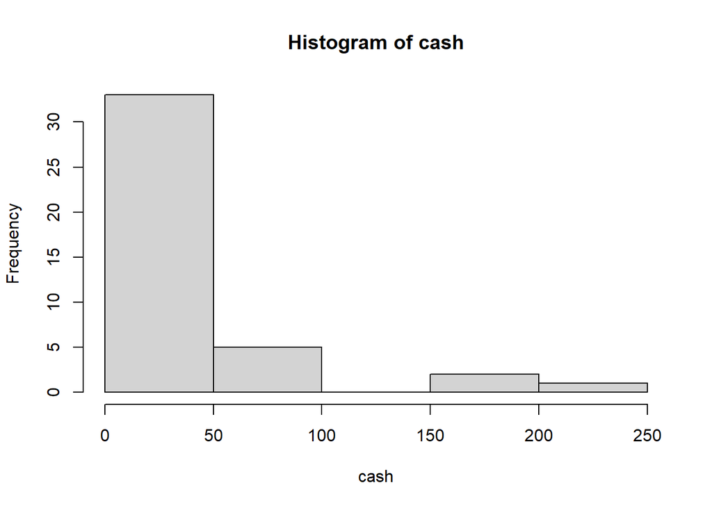

```r
#First, enter in the data as a vector
cash <- c(.05,6,30,0,65,4.75,50,0,100,.17,15,210,2,175,42,65,2,
          200,0,10,0,15,20,30,
          12,0,30,45,7,10,80,12,28,.75,100,33,1,14,5,23,45)

#To create the histogram, we'll use the R function hist
hist(cash)
```

Let’s take the “cash” data and use more dynamic code to plot a better-looking histogram.

To create the histogram, we’re going to use ggplot2, which is a really dynamic plotting package that we will use a LOT this semester and next. This means you need to install the ggplot2 package. *Go down to the console below and type: install.packages(“ggplot2”). Hit enter.* This will install ggplot2 (remember, you can check your package list in the bottom right block in R studio to see if it installed).

```r
#To actually USE ggplot, we need to make sure the library is open.
library(ggplot2)
```

Now, we’re ready to plot our histogram (or anything else we want to plot!).

```r
#One IMPORTANT note -- ggplot doesn't like dealing with lone vectors... it expects you to pass it a data.frame. All we have to do is save our "cash" vector as a dataframe using our trusty data.frame function.
cashdata <- data.frame(val=cash)

#NOW for the plotting!
histplot <- ggplot(cashdata, aes(x=val)) +  geom_histogram(binwidth=5, color="blue", fill="pink")

#the line above specifies our dataframe and then the variable we want to plot (look at your dataframe to get the name of your variable, in this case it is "val"). ggplot tells R we're building a plot, and "aes" stands for aesthetics. The beginning of the line will SAVE our plot as "histplot" (remember, you choose the name!)

#the code after the + tells R that I want it to plot a histogram (geom_histogram), I want my bin widths to be 5 (you can change this to whatever number you want) and I want my bars to be blue (you can change this) and the bars to be filled in pink (you can change this).

#Q: Now, what if I want to "print" this plot? What would I type next? (scroll down to see the answer)
```

A: I would just type the name of the plot! That’s how I “print” it!

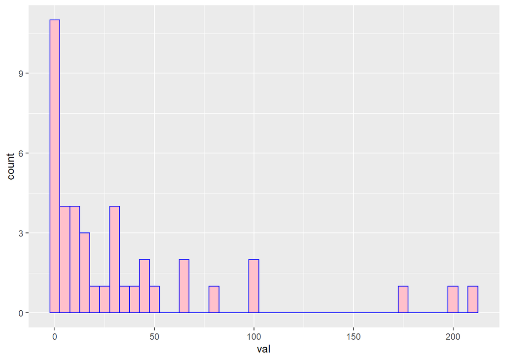

```r
histplot
```

NOTE: If I don’t “print” my plot, it won’t actually show up in my knit output file.

As the final step - go ahead and “knit” this file and see what you get. Pretty cool, huh?